# Forests do not limit bumble bee foraging movements in a montane meadow complex

John M. Mola, Michael R. Miller, Sean M. O’Rourke, Neal M. Williams

3/4/2020

# Purpose

The purpose of this document is to display all results needed for the manuscript in one location. Assuming the user has run all previous scripts in the “analyses” directory, this markdown should render the figures, statistical summaries, and tables needed to review the data analysis portions of the manuscript.

Please let me know if you have any questions by contacting me at jmola@usgs.gov

# Table 1

```
## # A tibble: 3 x 3
## # Groups:   species [2]
##   species       year     n
##   <chr>        <dbl> <int>
## 1 bifarius      2015   161
## 2 bifarius      2018   240
## 3 vosnesenskii  2015   332
```

```
## # A tibble: 3 x 3
## # Groups:   species [2]
##   species       year     n
##   <chr>        <dbl> <int>
## 1 bifarius      2015   148
## 2 bifarius      2018   207
## 3 vosnesenskii  2015   192
```

```
## # A tibble: 3 x 4
##   df.name ml.colony.num CI.lower CI.upper
##   <chr>           <dbl>    <dbl>    <dbl>
## 1 vsw15             413      406      539
## 2 bsw15            1007      712     2175
## 3 bsw18             975      816     1535
```

Individually tagged and recaptured bees:

```
## # A tibble: 11 x 3
##    site.1 site.2 distance
##    <chr>  <chr>     <dbl>
##  1 JMX    SH      3406.
##  2 JM03   JM04     535.
##  3 JM05   JM07     318.
##  4 JM03   JM03      64.6
##  5 JMX    JMX       49.9
##  6 JM06   JM06      43.7
##  7 JM10   JM10      40.2
##  8 JM04   JM04      16.8
##  9 JM01   JM01       4.54
## 10 JM10   JM10       4.25
## 11 JM04   JM04       2.81
```

## Figures 1 and 2 created in QGIS and Powerpoint

# Figure 3

### And associated statistics

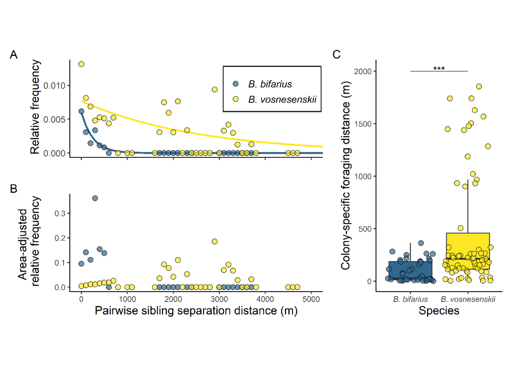

Sibling separation distances

```
## # A tibble: 2 x 5
##   species      median    q1    q3     n
##   <chr>         <dbl> <dbl> <dbl> <int>
## 1 bifarius       49.5  23.4  366.    55
## 2 vosnesenskii  334.  170.   577.   302
```

Sibling separation Wilcoxon test

```
##
##  Wilcoxon rank sum test with continuity correction
##
## data:  distance by species
## W = 4318, p-value = 1.486e-08
## alternative hypothesis: true location shift is not equal to 0
```

Colony-specific foraging distances

```
## # A tibble: 2 x 5
##   species      median    q1    q3     n
##   <chr>         <dbl> <dbl> <dbl> <int>
## 1 bifarius       25.3  13.5  187.    39
## 2 vosnesenskii  213.  114.   459.    66
```

Colony-specific foraging distance Wilcoxon test

```
##
##  Wilcoxon rank sum test with continuity correction
##
## data:  col.ctr.dist by species
## W = 620, p-value = 9.865e-06
## alternative hypothesis: true location shift is not equal to 0
```

Relative frequency models summary

```
## Call:
##   Model: nm ~ r1 | NULL
##    Data: combined_annulus
##
## Coefficients:
##    (Intercept)
##               Estimate Std. Error   z value      Pr(>|z|)
## bifarius     -5.115907 0.16982803 -30.12404 2.347286e-199
## vosnesenskii -4.861056 0.07096922 -68.49527  0.000000e+00
##    r1
##                   Estimate   Std. Error   z value     Pr(>|z|)
## bifarius     -0.0039732487 7.899751e-04 -5.029587 4.915370e-07
## vosnesenskii -0.0003977066 6.436513e-05 -6.178914 6.454415e-10
```

Area-adjusted models summary

```
## Call:
##   Model: sum_fi ~ r1 | NULL
##    Data: combined_annulus
##
## Coefficients:
##    (Intercept)
##               Estimate Std. Error    z value   Pr(>|z|)
## bifarius     -1.230461   1.389394 -0.8856095 0.37582797
## vosnesenskii -3.768846   2.055950 -1.8331413 0.06678157
##    r1
##                   Estimate   Std. Error    z value  Pr(>|z|)
## bifarius     -2.212061e-03 0.0029323217 -0.7543719 0.4506260
## vosnesenskii  8.151034e-05 0.0007637542  0.1067233 0.9150085
```

# Figure 4

### And associated statistics

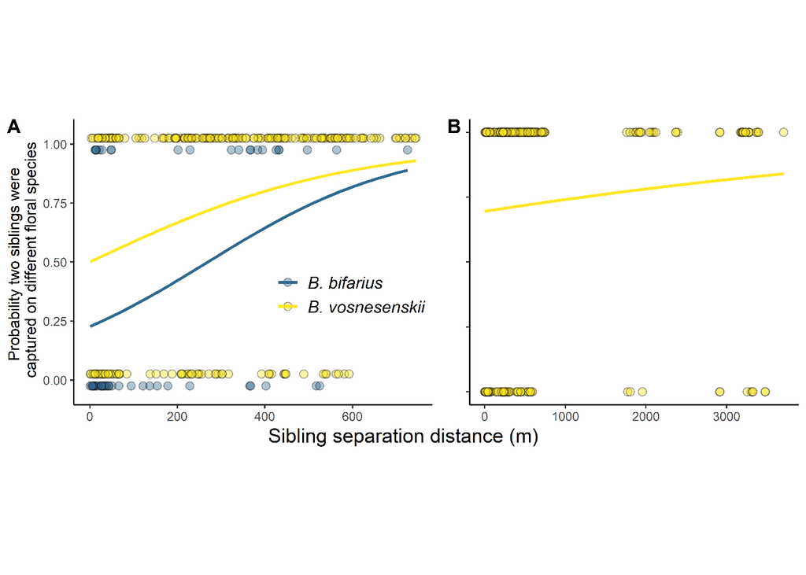

Sibling plant usage model summary

```
## Call:
##   Model: diff_plant ~ distance | NULL
##    Data: filter(sib_sep_combo, distance < 1000)
##
## Coefficients:
##    (Intercept)
##                  Estimate Std. Error      z value    Pr(>|z|)
## bifarius     -1.227637818  0.4204656 -2.919710290 0.003503569
## vosnesenskii  0.001739629  0.2338621  0.007438695 0.994064835
##    distance
##                 Estimate   Std. Error  z value     Pr(>|z|)
## bifarius     0.004556370 0.0016420122 2.774870 5.522381e-03
## vosnesenskii 0.003461663 0.0007737611 4.473813 7.683682e-06
```

Sibling plant usgae model summary for vosnesenskii only

```
##
## Call:
## glm(formula = diff_plant ~ distance, family = "binomial", data = .)
##
## Deviance Residuals:
##     Min       1Q   Median       3Q      Max
## -1.8924  -1.5438   0.8077   0.8302   0.8516
##
## Coefficients:
##              Estimate Std. Error z value Pr(>|z|)
## (Intercept) 0.8267710  0.1581979   5.226 1.73e-07 ***
## distance    0.0002244  0.0001539   1.458    0.145
## ---
## Signif. codes:  0 '***' 0.001 '**' 0.01 '*' 0.05 '.' 0.1 ' ' 1
##
## (Dispersion parameter for binomial family taken to be 1)
##
##     Null deviance: 355.16  on 301  degrees of freedom
## Residual deviance: 352.83  on 300  degrees of freedom
## AIC: 356.83
##
## Number of Fisher Scoring iterations: 4
```

Sibling plant usage, restricted to within 3 days, summary

```
## Call:
##   Model: diff_plant ~ distance | NULL
##    Data: filter(sib_sep_combo, distance < 1000, days_between <= 3)
##
## Coefficients:
##    (Intercept)
##               Estimate Std. Error   z value    Pr(>|z|)
## bifarius     -1.461934  0.5572510 -2.623476 0.008703769
## vosnesenskii -0.908658  0.3674535 -2.472851 0.013403985
##    distance
##                 Estimate  Std. Error  z value    Pr(>|z|)
## bifarius     0.008086988 0.003126508 2.586588 0.009693147
## vosnesenskii 0.003524923 0.001241210 2.839908 0.004512655
```

# Figure 5

### And associated statistics

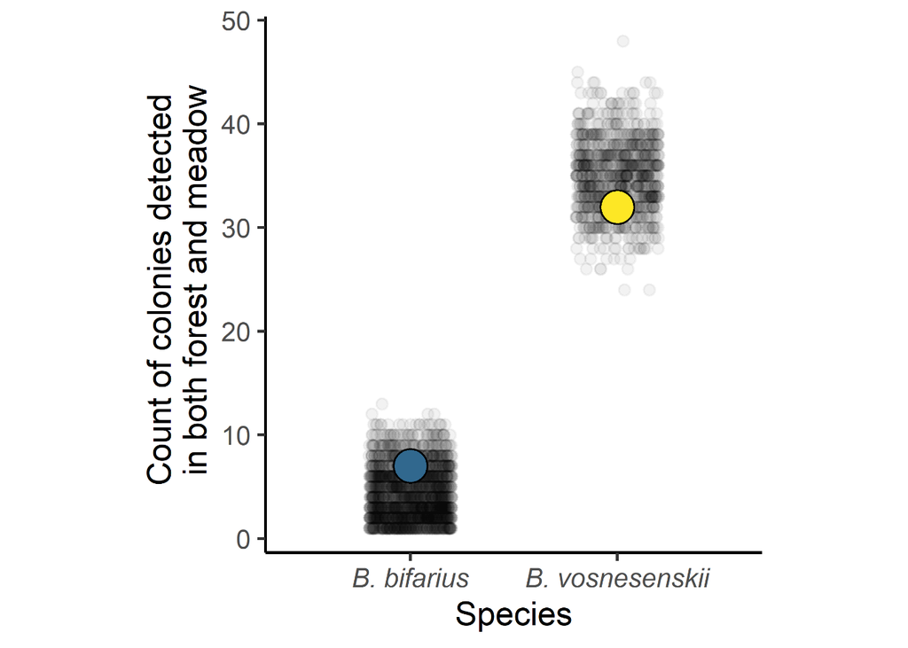

Observed numbers of colonies detected in forest and meadow

```
## # A tibble: 2 x 2
##   species             n
##   <chr>           <int>
## 1 B. bifarius         7
## 2 B. vosnesenskii    32
```

Summary of randomized crossings

[output not shown]

# Figure 6

### And associated statistics

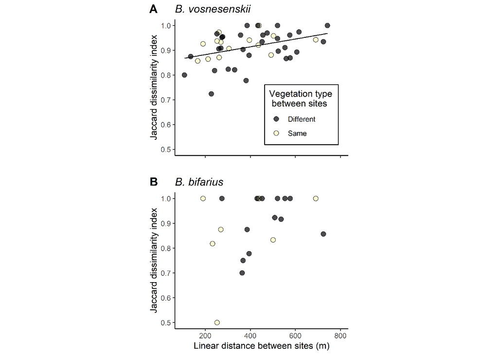

Summary of jaccard dissimilarity model for vosnesenskii

```
##
## Call:
## lm(formula = dis.distance ~ dist, data = nmds.dis.distance)
##
## Residuals:
##      Min       1Q   Median       3Q      Max
## -0.16291 -0.03342  0.01221  0.04360  0.08792
##
## Coefficients:
##              Estimate Std. Error t value Pr(>|t|)
## (Intercept) 8.514e-01  2.359e-02  36.093   <2e-16 ***
## dist        1.575e-04  5.548e-05   2.838   0.0069 **
## ---
## Signif. codes:  0 '***' 0.001 '**' 0.01 '*' 0.05 '.' 0.1 ' ' 1
##
## Residual standard error: 0.0588 on 43 degrees of freedom
## Multiple R-squared:  0.1578, Adjusted R-squared:  0.1382
## F-statistic: 8.055 on 1 and 43 DF,  p-value: 0.0069
```

Summary of jaccard dissimilarity model for bifarius

```
##
## Call:
## lm(formula = dis.distance ~ dist, data = bif_dissim)
##
## Residuals:
##      Min       1Q   Median       3Q      Max
## -0.33854 -0.08491  0.02116  0.09738  0.18138
##
## Coefficients:
##              Estimate Std. Error t value Pr(>|t|)
## (Intercept) 0.7579079  0.0905049   8.374 8.44e-08 ***
## dist        0.0003200  0.0001988   1.609    0.124
## ---
## Signif. codes:  0 '***' 0.001 '**' 0.01 '*' 0.05 '.' 0.1 ' ' 1
##
## Residual standard error: 0.1277 on 19 degrees of freedom
## Multiple R-squared:   0.12,  Adjusted R-squared:  0.07365
## F-statistic:  2.59 on 1 and 19 DF,  p-value: 0.124
```

Summary of jaccard dissimilarity model with interaction for vosnesenskii

```
##
## Call:
## lm(formula = dis.distance ~ dist * hab.cross, data = nmds.dis.distance)
##
## Residuals:
##      Min       1Q   Median       3Q      Max
## -0.14858 -0.04259  0.01753  0.02809  0.09639
##
## Coefficients:
##                      Estimate Std. Error t value Pr(>|t|)
## (Intercept)         8.287e-01  2.945e-02  28.136   <2e-16 ***
## dist                1.943e-04  6.612e-05   2.938   0.0054 **
## hab.crosssame       5.532e-02  5.060e-02   1.093   0.2807
## dist:hab.crosssame -8.385e-05  1.278e-04  -0.656   0.5153
## ---
## Signif. codes:  0 '***' 0.001 '**' 0.01 '*' 0.05 '.' 0.1 ' ' 1
##
## Residual standard error: 0.05876 on 41 degrees of freedom
## Multiple R-squared:  0.198,  Adjusted R-squared:  0.1393
## F-statistic: 3.374 on 3 and 41 DF,  p-value: 0.02731
```

Summary of jaccard dissimilarity model with interaction for bifarius

```
##
## Call:
## lm(formula = dis.distance ~ dist * hab.cross, data = bif_dissim)
##
## Residuals:
##      Min       1Q   Median       3Q      Max
## -0.32929 -0.09442  0.00630  0.09597  0.19532
##
## Coefficients:
##                      Estimate Std. Error t value Pr(>|t|)
## (Intercept)         0.8008959  0.1587457   5.045 9.97e-05 ***
## dist                0.0002281  0.0003296   0.692    0.498
## hab.crosssame      -0.0712161  0.1999635  -0.356    0.726
## dist:hab.crosssame  0.0001673  0.0004441   0.377    0.711
## ---
## Signif. codes:  0 '***' 0.001 '**' 0.01 '*' 0.05 '.' 0.1 ' ' 1
##
## Residual standard error: 0.1345 on 17 degrees of freedom
## Multiple R-squared:  0.1272, Adjusted R-squared:  -0.02677
## F-statistic: 0.8262 on 3 and 17 DF,  p-value: 0.4975
```

# Supplemental Figure

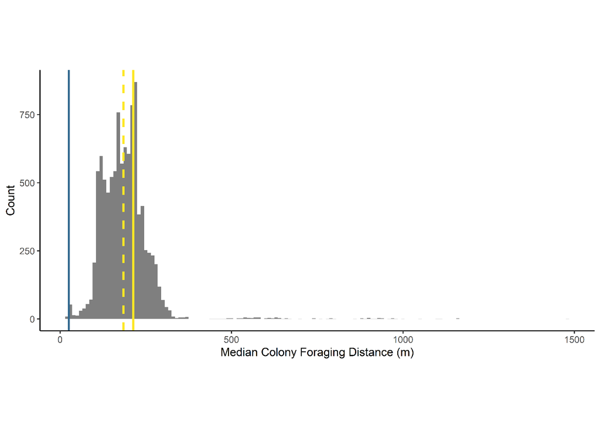

Subsampling summary table

```
## # A tibble: 1 x 5
##   prop25 total25  mean    sd median
##    <dbl>   <int> <dbl> <dbl>  <dbl>
## 1  0.999    9991  188.  75.4   185.
```